# A Comparison of Document-level Embeddings for Scientific Text

There are a number of ways to embed a scientific text $d$ as a (possibly high-dimensional) vector $v_d \in \mathbb{R}^n$

$$ \begin{align} \mathcal{D} &\rightarrow \mathbb{R}^n \\ d &\mapsto v_d \end{align} $$

where:

- $\mathcal{D}$ is a collection of scientific texts or documents,
- and $n$ is the 'embedding dimension'

Here we consider the following techniques:

- One-hot embedding
- Word-to-vec
- Term Frequency Inverse Document Frequency (TFIDF)
- Latent Semantic Analysis (LSA)

We use **V-measure** to compare these embedding techniques (see below for a description).

## Evaluation metrics

- A clustering result satisfies **homogeneity** if all of its clusters contain only data points which are members of a single class.
- A clustering result satisfies **completeness** if all the data points that are members of a given class are elements of the same cluster.
- The **V-measure** is the harmonic mean between homogeneity and completeness

  ```
  v = 2 * (homogeneity * completeness) / (homogeneity + completeness)
  ```

In our case we are most interested in homogeneity and V-measure. Indeed, it is not a big problem if we have several clusters that represent the same subject. It is, however, a problem if one cluster consists of many different subjects. This is what homogeneity measures. (Completeness is the symmetric property).

# What is Document-embedding?

Similar to *word embeddings*, where a word $w$ in some fixed vocabulary is identified with a vector $v_w$ in some vector space $\mathbb{R}^n$, a *document embedding* identifies an entire document $d$ (e.g., a scientific text) with a vector $v_d \in \mathbb{R}^n$.

[figure not shown]

When we apply this embedding to a collection of documents $\mathcal{D}$, we can hope to find natural clusters:

[figure not shown]

# Document-embedding Techniques

Here is a birds-eye-view of the document embeddings we will compare.

[figure not shown]

# A Case Study: arXiv.math

- Our goal is to find a small number of clusters that effectively distinguish mathematics papers
- To demonstrate, we analyse abstracts from ~15,000 papers split into 10 subjects

# Our data

```python
arxiv = pd.read_pickle('data/arxiv.pkl')
arxiv.head()
```

|  | Abstract | Code |
| --- | --- | --- |
| 0 | [show, hierarchy, intersection, rigidity, prop... | 53 |
| 1 | [note, time, collision, independent, Brownian,... | 60 |
| 2 | [article, proof, results, Blanc, Finite, Abeli... | 14 |
| 3 | [discuss, asymptotic, behaviour, models, latti... | 05 |
| 4 | [smooth, projective, curve, cycles, secant, pl... | 14 |

- There are 14,402 papers in our `arxiv` dataframe
- Each paper is tagged with one of 10 codes
- There are 11,198 words in our vocabulary

# Summary of results

A shortcut to the performance of these different techniques.

| Technique | Homogeneity (%) | V-measure (%) |
| --- | --- | --- |
| one-hot | 14.2 | 18.6 |
| word-to-vec | 55.0 | 54.8 |
| tfidf | 52.4 | 52.8 |
| lsa | 53.9 | 53.7 |

We see how these clusters interact with the true MSC codes.

[figure not shown]

(Here the (i,j) entry counts the number of papers in cluster-i and with code-j)

We see that the 'one-hot' embedding performs poorly compared to the others. The other three are fairly similar. Perhaps an ensemble method combining these embeddings would give the best performance.

What follows is the code that produces these data.

Alternatively, produce them yourself with the script:

```
$ python3 comparison_of_document_embeddings.py
```

available at https://github.com/aminsaied (soon!)

# One-hot representations

We start with the most naive approach. Embed each paper as sum of the one-hot vectors of the words it contains. Simple as that.

```python
X_oh = k_means_data_as_one_hot_from_df(arxiv, vocab)
print('One-hot representation has shape', X_oh.shape)
```

```
One-hot representation has shape (14402, 11198)
```

```python
n_clusters = len(codes) # in our case, that is 10

km_oh = MiniBatchKMeans(n_clusters=n_clusters, batch_size=1000)
km_oh.fit(X_oh)
```

```
MiniBatchKMeans(batch_size=1000, compute_labels=True, init='k-means++',
        init_size=None, max_iter=100, max_no_improvement=10, n_clusters=10,
        n_init=3, random_state=None, reassignment_ratio=0.01, tol=0.0,
        verbose=0)
```

```python
# evaluate
print("Homogeneity: %0.3f" % metrics.homogeneity_score(labels, km_oh.labels_))
print("Completeness: %0.3f" % metrics.completeness_score(labels, km_oh.labels_))
print("V-measure: %0.3f" % metrics.v_measure_score(labels, km_oh.labels_))
```

```
Homogeneity: 0.142
Completeness: 0.270
V-measure: 0.186
```

A V-meaure of 18.6% is not great! We can do better.

# Word-to-vec representations

Similar approach, only now we use word-to-vec embeddings from a pre-trained word-to-vec model to embed words.

```python
# embed our dataset into R^dim_w2v
X_w2v = k_means_data_as_w2v_from_abstracts(ab_list, w2v)
print('Word-to-vec representation has shape', X_w2v.shape)
```

```
Word-to-vec representation has shape (14402, 50)
```

(It can make a significant difference to the performance of k-means if the data are normalized)

```python
normalizer = Normalizer(copy=False)
X_w2v = normalizer.transform(X_w2v)
```

```python
# fit k-means with 10 clusters
km_w2v = KMeans(n_clusters)
km_w2v.fit(X_w2v)
```

```
KMeans(algorithm='auto', copy_x=True, init='k-means++', max_iter=300,
    n_clusters=10, n_init=10, n_jobs=1, precompute_distances='auto',
    random_state=None, tol=0.0001, verbose=0)
```

```python
print("Homogeneity: %0.3f" % metrics.homogeneity_score(labels, km_w2v.labels_))
print("Completeness: %0.3f" % metrics.completeness_score(labels, km_w2v.labels_))
print("V-measure: %0.3f" % metrics.v_measure_score(labels, km_w2v.labels_))
```

```
Homogeneity: 0.550
Completeness: 0.546
V-measure: 0.548
```

That is much better! A V-measure of >50% is capturing a reasonable amount of the underlying structure.

### Comparison with the true labels

Here we picture how well the clusters are identifying the underlying true labels. Each row represents a cluster in the word-to-vec embedding, and each column represents a true class label. We then sort our data into these row/column bins as appropriate.

[figure not shown]

From this image we can see, for example:

- word-to-vec cluster 2 $\leftrightarrow$ msc-code at index 9
- word-to-vec cluster 7 $\leftrightarrow$ msc-code at index 0
- word-to-vec cluster 8: this cluster is more confused...

We can contrast this plot with the poorly performing one-hot embedding.

[figure not shown]

We see that the one-hot embedding fails to identify the true labels well. Mostly it groups around one large cluster (cluster 5).

# TFIDF representations

TFIDF is a means to assign relevance to words in the vocabulary by measuring

- how often a word appears (Term Frequency)
- how spread out that word is across the corpus of text (Inverse Document Frequency)

```python
max_features = 10000
vectorizer = TfidfVectorizer(max_df=0.5, max_features=max_features,
                             ngram_range=(1,4),
                             min_df=2, stop_words='english',
                             use_idf=True)

X_tfidf = vectorizer.fit_transform(abs_corpus)
print('Tf-Idf representation has shape', X_tfidf.shape)
```

```
Tf-Idf representation has shape (14402, 10000)
```

```python
km_tfidf = MiniBatchKMeans(n_clusters=n_clusters, init='k-means++', batch_size=1000)
km_tfidf.fit(X_tfidf)
```

```
MiniBatchKMeans(batch_size=1000, compute_labels=True, init='k-means++',
        init_size=None, max_iter=100, max_no_improvement=10, n_clusters=10,
        n_init=3, random_state=None, reassignment_ratio=0.01, tol=0.0,
        verbose=0)
```

```python
print("Homogeneity: %0.3f" % metrics.homogeneity_score(labels, km_tfidf.labels_))
print("Completeness: %0.3f" % metrics.completeness_score(labels, km_tfidf.labels_))
print("V-measure: %0.3f" % metrics.v_measure_score(labels, km_tfidf.labels_))
```

```
Homogeneity: 0.524
Completeness: 0.531
V-measure: 0.528
```

### Comparison with the true labels

[figure not shown]

# Latent Semantic Analysis (LSA)

The TFIDF data still has 10,000-dimensional vectors. The idea behind LSA is to use the singular value decomposition to learn the a smaller number of important *concepts* and just use those.

```python
n_components = 18
svd = TruncatedSVD(n_components)
normalizer = Normalizer(copy=False)
lsa = make_pipeline(svd, normalizer)

X_lsa = lsa.fit_transform(X_tfidf)
print('LSA representation has shape', X_lsa.shape)
```

```
LSA representation has shape (14402, 18)
```

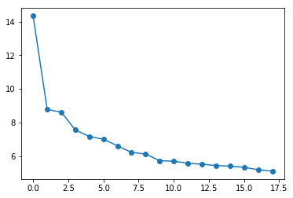

```python
# let's see how the singular values drop off
plt.plot(svd.singular_values_, 'o-')
plt.show()
```

```python
km_lsa = KMeans(n_clusters=n_clusters, n_init=20)
km_lsa.fit(X_lsa)
```

```
KMeans(algorithm='auto', copy_x=True, init='k-means++', max_iter=300,
    n_clusters=10, n_init=20, n_jobs=1, precompute_distances='auto',
    random_state=None, tol=0.0001, verbose=0)
```

```python
print("Homogeneity: %0.3f" % metrics.homogeneity_score(labels, km_lsa.labels_))
print("Completeness: %0.3f" % metrics.completeness_score(labels, km_lsa.labels_))
print("V-measure: %0.3f" % metrics.v_measure_score(labels, km_lsa.labels_))
```

```
Homogeneity: 0.539
Completeness: 0.534
V-measure: 0.537
```

### Comparison with the true labels

[figure not shown]

- Notice that the MSC classes 4 and 5 are both labelled as LSA-cluster 1
- Otherwise there is a nice even spread

# Combined embeddings

## e.g. LSA + Word-to-vec

Something else we try is to combine different embeddings.

```python
X_lsa_w2v = np.concatenate([X_lsa,X_w2v], axis=1)
print('The shape of X_lsa is', X_lsa.shape)
print('The shape of X_w2v is', X_w2v.shape)
print('The combined shape is therefore', X_lsa_w2v.shape)
```

```
The shape of X_lsa is (14402, 18)
The shape of X_w2v is (14402, 50)
The combined shape is therefore (14402, 68)
```

```python
km_lsa_w2v = KMeans(n_clusters=n_clusters)
km_lsa_w2v.fit(X_lsa_w2v)
```

```
KMeans(algorithm='auto', copy_x=True, init='k-means++', max_iter=300,
    n_clusters=10, n_init=10, n_jobs=1, precompute_distances='auto',
    random_state=None, tol=0.0001, verbose=0)
```

```python
print("Homogeneity: %0.3f" % metrics.homogeneity_score(labels, km_lsa_w2v.labels_))
print("Completeness: %0.3f" % metrics.completeness_score(labels, km_lsa_w2v.labels_))
print("V-measure: %0.3f" % metrics.v_measure_score(labels, km_lsa_w2v.labels_))
```

```
Homogeneity: 0.567
Completeness: 0.570
V-measure: 0.568
```

# Hashing

```python
hasher = HashingVectorizer(n_features=2**18,
                           stop_words='english', alternate_sign=False,
                           norm=None, binary=False)

vectorizer = make_pipeline(hasher, TfidfTransformer())
X_hash = vectorizer.fit_transform(abs_corpus)
```

```python
km_hash = MiniBatchKMeans(n_clusters=n_clusters)
km_hash.fit(X_hash)
```

```
MiniBatchKMeans(batch_size=100, compute_labels=True, init='k-means++',
        init_size=None, max_iter=100, max_no_improvement=10, n_clusters=10,
        n_init=3, random_state=None, reassignment_ratio=0.01, tol=0.0,
        verbose=0)
```

```python
print("Homogeneity: %0.3f" % metrics.homogeneity_score(labels, km_hash.labels_))
print("Completeness: %0.3f" % metrics.completeness_score(labels, km_hash.labels_))
print("V-measure: %0.3f" % metrics.v_measure_score(labels, km_hash.labels_))
```

```
Homogeneity: 0.407
Completeness: 0.460
V-measure: 0.432
```